# Data Sources and Manipulation

INST447 · Week 1 · Fall 2026

Wei Ai

September 3, 2026

# Part I: Data science in the messy middle

## Data science begins with a question

Data science is the study of data in order to understand something, decide something, or build something.

The code matters—but it is one link in a longer chain of choices.

## Data has a lifecycle

Question**→**Data**→**Analysis**→**Explanation or decision**↺**

At every arrow, somebody makes a decision.

## A data pipeline is a sequence of decisions

Define**→**Locate**→**Acquire**→**Inspect + clean**→**Transform + combine**→**Analyze**→**Communicate

A result is only as trustworthy as the choices that produced it.

## INST447 lives in the messy middle

### You start with a question

Goals, constraints, and real-world context

→

### You need a credible answer

Analysis, decisions, and communication

Between the question and the answer is the **messy middle**: locate, acquire, inspect, clean, reshape, combine, and validate data. That is this course.

## This course is about making data usable—and believable

- Common files and semi-structured formats
- Filtering, grouping, joining, and reshaping
- APIs and basic web data
- Cleaning and standardization
- Validation and sanity checks
- Reproducible, explainable workflows

## But we all know…

There is an elephant in the classroom.

## The elephant in the classroom

[figure not shown]

A large elephant marked AI sits in a university lecture hall, facing a laptop while students sit around it.

## AI changes how the work gets done

AI changes how some of this work gets done. It does not remove the need to understand the work.

## Last year, I tried “vibe coding”

These examples are from 2025.

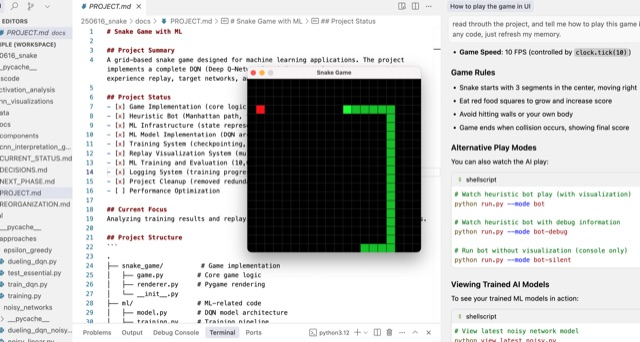

Snake + deep Q-learning

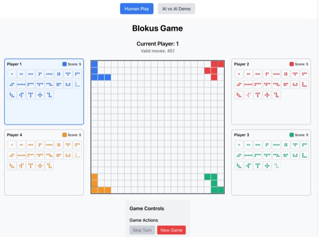

Blokus + search

[figure not shown]

## … and this year: a tangram website with GPT-5.6 Sol

[figure not shown]

Create

[figure not shown]

Play

[figure not shown]

Print

**4**rounds of conversation

**30 min**GPT time

**2 hr**human typing time

## The lessons from 2025 still hold

1. **Taste and judgment matter.** The tool cannot decide what “good” means for your situation.
2. **Complexity accumulates quietly.** It gets easy to lose track of a large generated codebase.
3. **The tool amplifies your skill.** Programming and data knowledge make it easier to specify, debug, and review.

## AI goes beyond suggesting the next line

| Coding assistant | Coding agent |
| --- | --- |
| Works mainly in the current file or chat | Inspects a repository and its instructions |
| Suggests code for you to place | Edits files and runs commands |
| Waits for each next prompt | Iterates through several steps |
| You execute and inspect each change | You review the plan, evidence, and diff |

The center of gravity moves from typing toward specifying, steering, and verifying.

## Agentic coding is a loop, not a single prompt

State a goal**→**Inspect context**→**Plan**→**Edit**→**Run + check**→**Report evidence

**Human gate:** accept, redirect, investigate, or stop.

## What did the human contribute across those rounds?

### Before and during

- Describing the goal
- Choosing constraints and priorities
- Clarifying what the agent misunderstood

### After each round

- Testing the output
- Noticing defects and awkward behavior
- Deciding what to keep, change, or reject

Some people talk about token maximization: spend as many AI tokens as possible and ship whatever comes back. What is wrong with that? Tokens do not replace judgment.

## More autonomy creates more ways to be wrong

### A program can run and still…

- answer the wrong question
- discard the wrong rows
- leak information across train and test data
- encode a false assumption

### An agent can also…

- edit beyond the intended scope
- trust a weak test
- expose a credential
- make many wrong changes quickly

## What you remain responsible for when AI writes code

| Your responsibility | Example |
| --- | --- |
| **Understand the task and the data** | Explain what one row represents and what the code should output. |
| **Read and make a small change** | Adjust a filter or selected field using an example and documentation. |
| **Run validation and sanity checks** | Compare row counts before and after a join; inspect missing values and duplicates. |
| **Protect data, keys, and the integrity of your submission** | Keep API keys out of notebooks and never upload private data without permission. |

## A useful division of labor

### AI can help

- brainstorm approaches
- draft or modify code
- explain unfamiliar syntax
- run repetitive checks
- surface possible problems

### You remain accountable

- define the question
- understand the data
- choose what evidence matters
- verify the result
- explain what you submit

AI tools are welcome. Responsibility does not transfer to the tool.

## How does that affect our professional career?

### Experience can compound

**Senior developers** often have more context for decomposition, tradeoffs, debugging, and review—so capable tools can amplify that judgment.

### Practice can disappear

If agents absorb junior-shaped implementation tasks, **newcomers** may lose some of the repetition through which they would have built that judgment.

Early evidence points to pressure on young workers in AI-exposed jobs, but productivity effects vary sharply by task and context.

## In 447, we should embrace AI at three levels

1. **AI as a coding assistant** — draft, debug, and explain code.
   - *“How could I change the name of this column?”*
   - *“How could I pivot the DataFrame into this format?”*
2. **AI as a data processor** — use an LLM through an API for structured extraction or augmentation.
   - *“Extract the named entities (people, places, etc.) in each tweet of this dataset.”*
   - *“Augment this congress-speech dataset with the NYT headline of the day.”*
3. **AI as an analysis pipeline** — brainstorm, plan, and audit an end-to-end workflow.

**Access matters:** no paid AI subscription, or paid API is required for required course work. AI coding assistance is *not* required for completing programming assignments.

Free resources available to you: **TerpAI** (UMD), **Gemini Education** (UMD Google account), and **Google AI Studio** (free-tier API).

# Part II: How the course works

## The semester keeps the same three-part arc

**1**Manipulatetables, text, joins, reshaping

**→**

**2**Acquire + structureJSON, XML, APIs, web data

**→**

**3**Analyze end to endagents, quality, ethics, documentation

## Part 1 builds the manipulation toolkit

| Date | Focus |
| --- | --- |
| Sep 3 | Introduction, workflow, and pipeline |
| Sep 10–17 | Filtering, transformation, grouping, joining, reshaping |
| Sep 24 | Visualization for validation; thinking at scale |
| Oct 1 | Text and practical regular expressions |

Goal: turn a messy table into evidence you can inspect and defend.

## Part 2 expands where data can come from

| Date | Focus |
| --- | --- |
| Oct 8 | JSON and XML |
| Oct 15 | APIs and web data |
| Oct 22 | AI for data processing |
| Oct 29 | Data-representation abstractions |

Goal: acquire data deliberately, then make its structure explicit.

## Part 3 connects the whole pipeline

| Date | Focus |
| --- | --- |
| Nov 5 | Agentic coding for iterative exploration |
| Nov 12 | Missing data, outliers, deduplication, and more |
| Nov 19 | Bias, ethics, and documentation |
| Dec 3–10 | Advanced topics, synthesis, and reflection |

Goal: use stronger tools without weakening the quality of the analysis.

## The weekly rhythm alternates explanation and practice

**Thursday**lecture + demos **→** **Tuesday**guided Colab lab **→** **Wednesday 11:59 p.m.**upload completed notebook **→** **Thursday**next concept

- Brief ELMS quizzes appear during selected lectures.
- Four programming assignments provide deeper checkups.
- A take-home midterm and final project connect multiple skills.

## The grading weights are unchanged

| Component | Weight |
| --- | --- |
| Weekly labs | **30%** |
| In-lecture quizzes | **10%** |
| Programming assignments (4) | **20%** |
| Take-home midterm project | **20%** |
| Final project | **20%** |

Frequent practice  
+  
two integrated projects

## A few deadline rules are worth remembering

### Labs

- Due Wednesday at 11:59 p.m.
- No late submission without an approved extension
- Lowest lab score automatically dropped

### Programming assignments

- Under 24 hours late: 10% penalty
- 24–48 hours late: 20% penalty
- Over 48 hours: not accepted without prior arrangements

## Ask for help early

### Where

- ELMS for materials, submissions, and announcements
- Email with **[INST447]** in the subject line
- Office hours for back-and-forth help

### Who

- Wei Ai, instructor
- Meiyu (Emily) Li, graduate TA
- Sukriti Srivastava, graduate course aide
- UTAs TBD
- Office hours will be posted in ELMS

Please do not wait until a deadline to tell us you are stuck.

## Recording Policy

- The instructor records class and normally posts it to Panopto on Friday.
- Students may not make additional recordings or send classroom audio or video to an AI transcription or summarization service without authorization.
- An approved ADS accommodation is an exception.
- Any authorized student recording is for personal course use and may not be shared.

## Questions before we switch to workflow?

Course structure · tools and costs · labs · grading · communication

# Part III: Work that can be retraced

## Use a workspace that makes the work visible

### Notebooks are useful for

- exploration
- immediate output
- narrative and plots
- guided labs

### An IDE or project workspace helps you see

- files and folders
- code and output
- terminal commands
- version-control changes

Agentic work is easier to review when the project has explicit structure.

## A reproducible analysis is a directed graph

Raw data  
immutable **→** Clean + validate **→** Transform **→** Analyze **→** Figures · tables · report

If one input changes, you should know what must be rerun.

## Notebooks explore; scripts repeat

| Notebook | Script or function |
| --- | --- |
| Ask a question interactively | Repeat a stable step |
| Inspect intermediate results | Apply the same logic reliably |
| Combine explanation, code, and output | Make dependencies easier to test |
| Easy to run out of order | Usually runs from a defined entry point |

Start by exploring. Move repeated logic into a form you can rerun and check.

## A directory structure is external memory

```
project/
├── README.md          what this project does
├── data/
│   ├── raw/           unchanged inputs
│   └── processed/     reproducible outputs
├── notebooks/         exploration
├── src/               reusable code
├── output/            figures and tables
└── tests/             checks that should keep passing
```

Good names and boundaries reduce the amount that must live in your head.

## The goal is not to type every line

The goal is to build a data workflow you can **understand, inspect, rerun, check, and explain.**

AI can accelerate the work. Those five verbs remain yours.

# A bit about my research

## Wei Ai — research overview

**Assistant Professor, INFO & UMIACS**

### Recent focus: AI for K-12 education

- Using AI/LLM to help teachers in K-12 classrooms
- Promoting high-quality instruction through automated feedback
- Reducing teachers’ workload and enhancing lesson planning with AI tools

### More broadly

Integrating heterogeneous expertise knowledge in behavior retrieval, measurement, and discovery

## The data challenges in this work

1. **Multimodal and messy data** — classroom video, audio, text, and structured records do not arrive clean
2. **Data scarcity, two kinds** — not enough labeled examples, and not enough of the rare events that matter most
3. **Getting expertise out of the data we do have** — translating what experienced teachers know into something a model can learn from
4. **Closing the loop with stakeholders** — research that does not reach teachers and schools does not improve instruction